# Line charts or why is Nebraska terrible?

By Matt Waite

Bar charts – stacked or otherwise – are good for showing relative size of a thing compared to another thing. Line charts, which we work on here, are good for showing change over time.

So let’s look at how we can answer this question: Why is Nebraska terrible right now?

One good thing about sports is that there’s lots of interest in it. And that means there’s outlets that put sports data on the internet. Now I’m going to show you a trick to getting it easily.

The site sports-reference.com takes NCAA (and other league) stats and puts them online. For instance, [here’s their page on Nebraska basketball’s game logs](https://www.sports-reference.com/cbb/schools/nebraska/2019-gamelogs.html), which you should open now.

Now, in a new tab, log into Google Docs/Drive and open a new spreadsheet. In the first cell of the first row, copy and paste this formula in:

```
=IMPORTHTML("https://www.sports-reference.com/cbb/schools/nebraska/2019-gamelogs.html", "table", 1)
```

If it worked right, you’ve got the data from that page in a spreadsheet.

### Cleaning the data

The first thing we need to do is recognize that we don’t have data, really. We have the results of a formula. You can tell by putting your cursor on that field, where you’ll see the formula again. This screenshot is from a different example, but this is where you’d look:

[figure not shown]

Cleaning data screenshot

The solution is easy:

Edit > Select All (command/control A) Edit > Copy (command/control c) Edit > Paste Special > Values Only) (command/control shift v)

Now you have data, but your headers are all wrong. You want your headers to be one line – not two, like they have. And the header names repeat – first for our team, then for theirs. So you have to change each header name to be UsORB or TeamORB and OpponentORB instead of just ORB.

After you’ve done that, note we have repeating headers. There’s two ways to deal with that – you could just hightlight it and go up to Edit > Delete Rows XX-XX depending on what rows you highlighted. That’s the easy way with our data.

But what if you had hundreds of repeating headers like that? Deleting them would take a long time.

You can use sorting to get rid of anything that’s not data. So click on Data > Sort Range. You’ll want to check the “Data has header row” field. Then hit Sort.

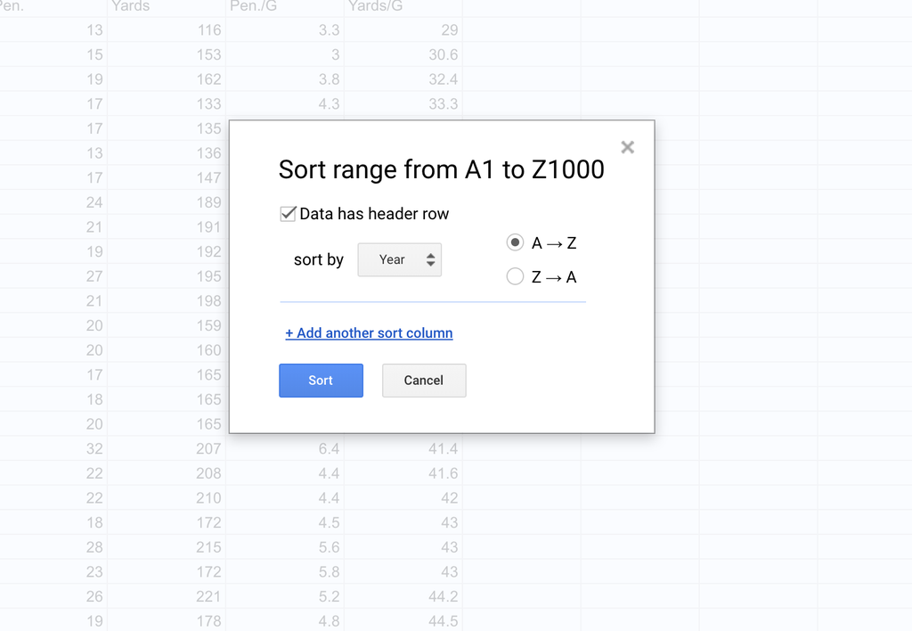

Cleaning data screenshot

Now all you need to do is search through the data for where your junk data – extra headers, blanks, etc. – got sorted and delete it. After you’ve done that, you can export it for use in R. Go to File > Download as > Comma Separated Values. Remember to put it in the same directory as your R Notebook file so you can import the data easily.

### Line charts

Let’s start getting all that we need. We can use the tidyverse shortcut.

```r
library(tidyverse)
```

Now we’ll import the data you created. Mine looks like this:

```r
nu <- read_csv("~/Dropbox/SPMC350-Data-Literacy-and-Analytics-in-Sports/Data/nulogs.csv")
```

Because this data has just Nebraska data in it, the dates are formatted correctly, and the data is long data (instead of wide), we have what we need to make line charts.

Now we have what we need. Let’s chart it.

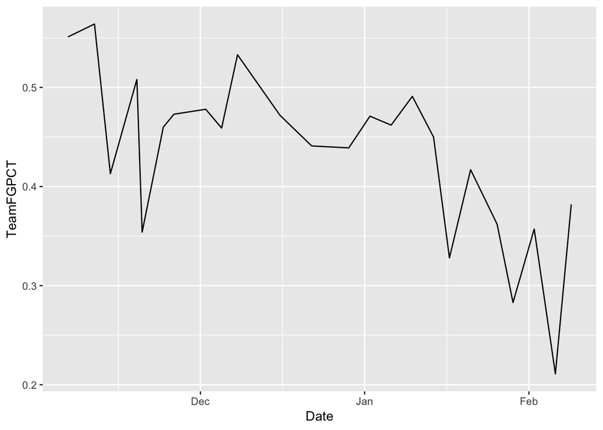

```r
ggplot(nu, aes(x=Date, y=TeamFGPCT)) + geom_line()
```

See a problem here? Note the Y axis doesn’t start with zero. That makes this look worse than it is (and it’s pretty bad). To make the axis what you want, you can use `scale_x_continuous` or `scale_y_continuous` and pass in a list with the bottom and top value you want. You do that like this:

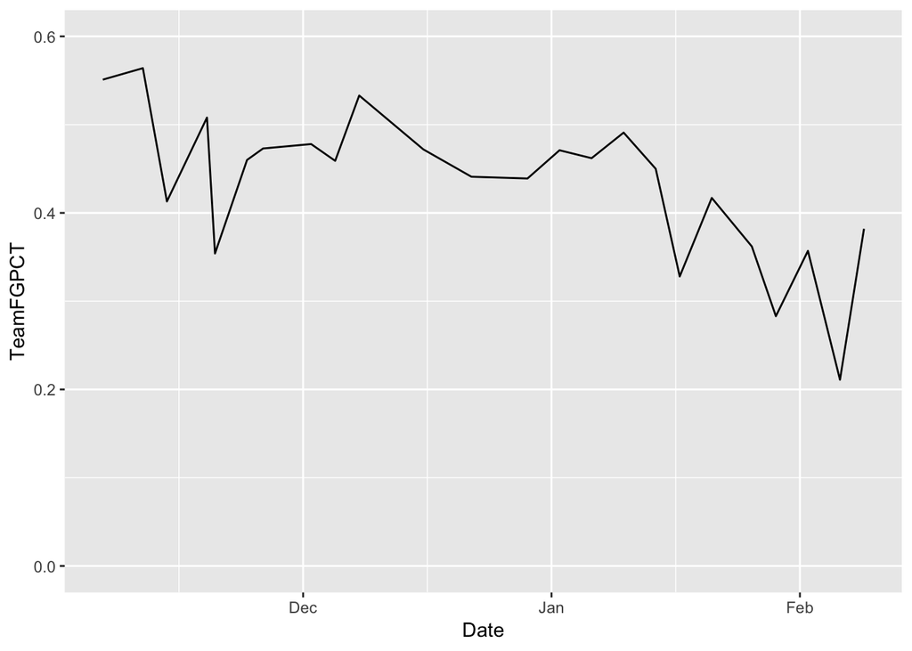

```r
ggplot(nu, aes(x=Date, y=TeamFGPCT)) + geom_line() + scale_y_continuous(limits = c(0, .6))
```

Note also that our X axis labels are automated. It knows it’s a date and it just labels it by month.

### This is too simple.

With datasets, we want to invite comparison. So let’s answer the question visually. Let’s put two lines on the same chart. How does Nebraska compare to Michigan? Go grab [Michigan’s data](https://www.sports-reference.com/cbb/schools/michigan/2019-gamelogs.html) same way you grabbed Nebraska’s. Save yourself some pain and copy and paste your field names.

In this case, because we have two different datasets, we’re going to put everything in the geom instead of the ggplot step. We also have to explicitly state what dataset we’re using by saying `data=` in the geom step. So import your data. Here’s what mine looks like:

```r
michigan <- read_csv("~/Dropbox/SPMC350-Data-Literacy-and-Analytics-in-Sports/Data/michlogs.csv")
```

First, let’s chart Nebraska. Read carefully. First we set the data. Then we set our aesthetic. Unlike bars, we need an X and a Y variable. In this case, our X is the season – the date data. Y is the thing we want the lines to move with. In this case, the Team Field Goal Percentage – or whatever you called it in your dataset.

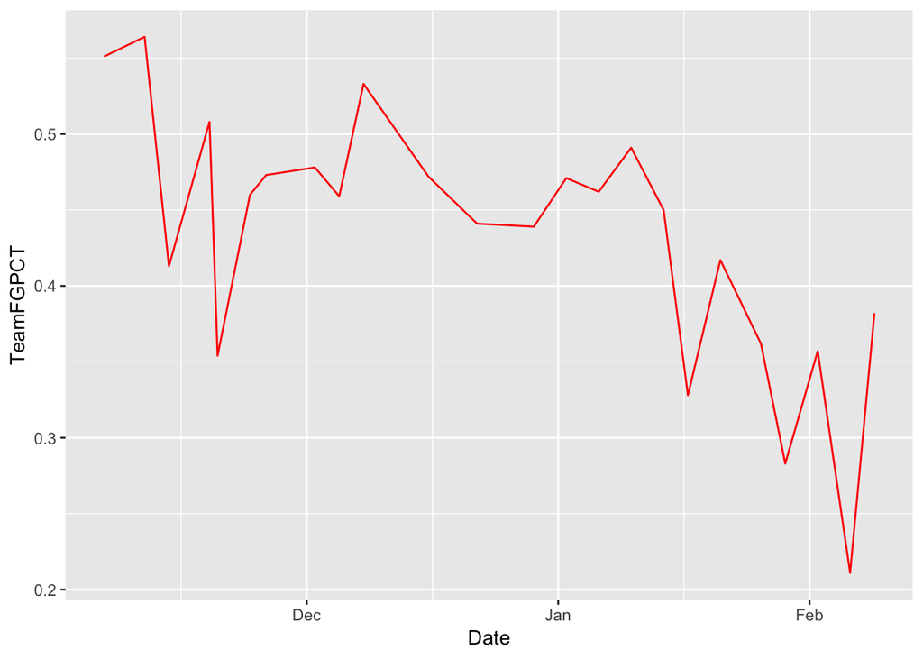

```r
ggplot() + geom_line(data=nu, aes(x=Date, y=TeamFGPCT), color="red")
```

Now, by using +, we can add Michigan to it. REMEMBER COPY AND PASTE IS A THING. Nothing changes except what data you are using.

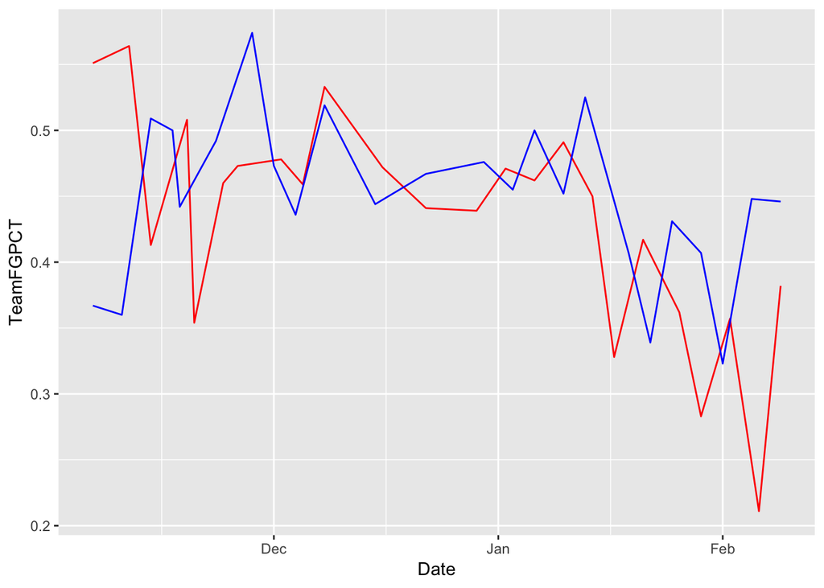

```r
ggplot() + geom_line(data=nu, aes(x=Date, y=TeamFGPCT), color="red") + geom_line(data=michigan, aes(x=Date, y=TeamFGPCT), color="Blue")
```

Let’s flatten our lines out by zeroing the Y axis.

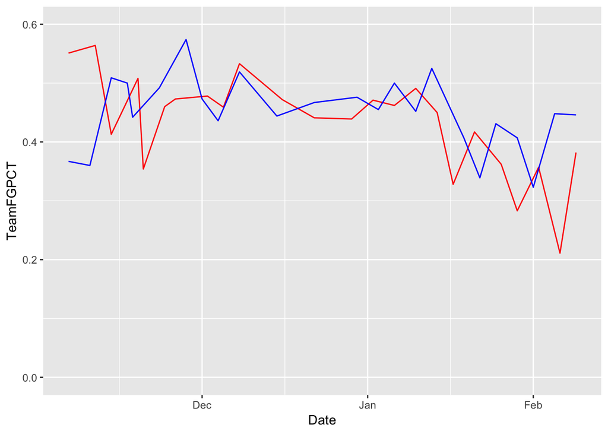

```r
ggplot() + geom_line(data=nu, aes(x=Date, y=TeamFGPCT), color="red") + geom_line(data=michigan, aes(x=Date, y=TeamFGPCT), color="Blue") + scale_y_continuous(limits = c(0, .6))
```

So visually speaking, Michigan doesn’t seem to be having a much better season than we are. Except they’re top of the Big Ten right now, and we’re … not.

### But what if I wanted to add a lot of lines.

```r
logs <- read_csv("~/Dropbox/SPMC350-Data-Literacy-and-Analytics-in-Sports/logs.csv")
```

I can keep layering on layers all day if I want. And if my dataset has more than one team in it, I need to use the `group` command. And, the layering comes in order – so if you’re going to layer a bunch of lines with a smaller group of lines, you want the bunch on the bottom. So to do that, your code stacks from the bottom. The first geom in the code gets rendered first. The second gets layered on top of that. The third gets layered on that and so on.

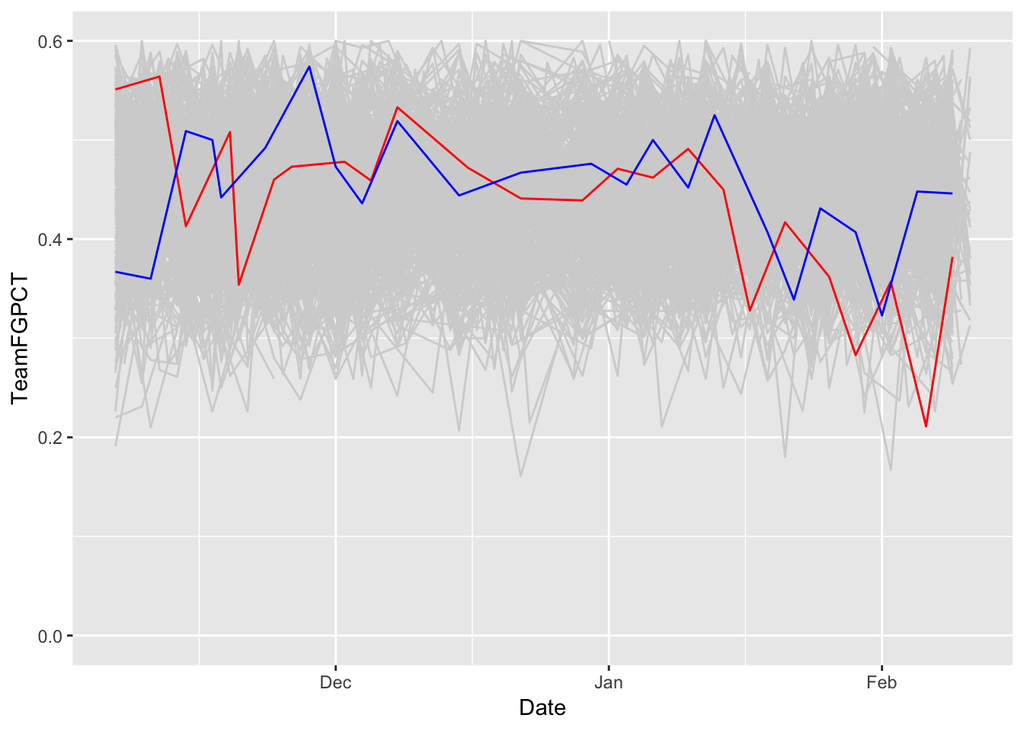

```r
ggplot() + geom_line(data=logs, aes(x=Date, y=TeamFGPCT, group=Team), color="light grey") + geom_line(data=nu, aes(x=Date, y=TeamFGPCT), color="red") + geom_line(data=michigan, aes(x=Date, y=TeamFGPCT), color="Blue") + scale_y_continuous(limits = c(0, .6))
```

What do we see here? How has Nebraska and Michigan’s season evolved against all the rest of the teams in college basketball?

But how does that compare to the average? We can add that pretty easily by creating a new dataframe with it and add another geom_line.

```r
average <- logs %>% group_by(Date) %>% summarize(mean_shooting=mean(TeamFGPCT))
```

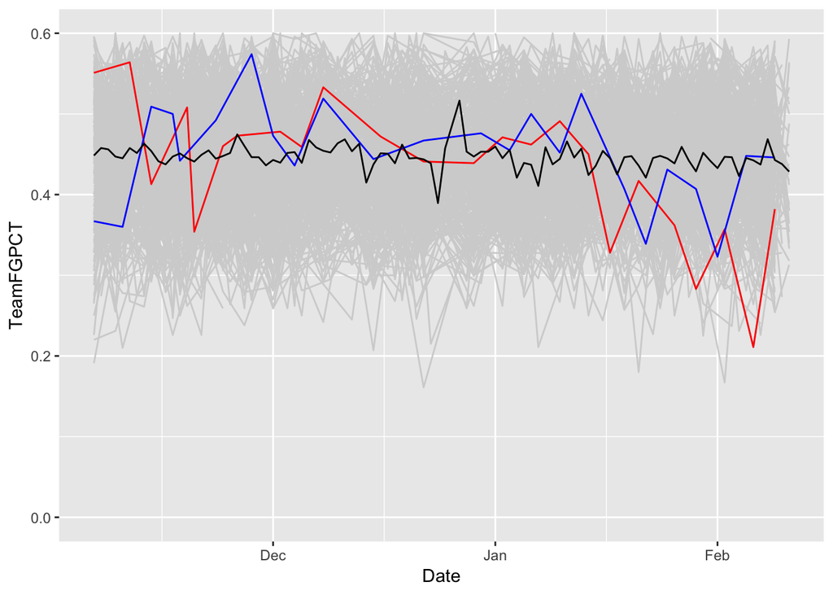

```r
ggplot() + geom_line(data=logs, aes(x=Date, y=TeamFGPCT, group=Team), color="light grey") + geom_line(data=nu, aes(x=Date, y=TeamFGPCT), color="red") + geom_line(data=michigan, aes(x=Date, y=TeamFGPCT), color="Blue") + geom_line(data=average, aes(x=Date, y=mean_shooting), color="black") + scale_y_continuous(limits = c(0, .6))
```

### Assignment

- How does Nebraska’s shooting percentage compare to the Big Ten? [I won’t make you scrape all of the teams](https://www.dropbox.com/s/pvq9nyao1xorvvd/biglogs.csv?dl=0). But to put the Big Ten on the same chart as Nebraska, you’ll need two dataframes, two geoms and with your Big Ten dataframe, you need to use `group` in the aesthetic.
- After working on this chart, your boss comes in and says they don’t care about field goal percentage anymore. They just care about three-point shooting because they read on some blog that three-point shooting was all the rage. Change what you need to change to make your line chart now about how the season has gone behind the three-point line. How does Nebraska compare to the rest of the Big Ten?

#### Rubric

1. Did you gather the data correctly?
2. Did you import it into R Notebook correctly?
3. Did you create the data frames needed to chart correctly?
4. Did you chart both correctly?